# RNA-seq_for_mig_exam

KN

2023-06-17

# Introduction

This is report file for the practical part of the Methods in Genomics exam. It is attempt to reproduce a part of an RNA-seq analysis from the following paper: https://doi.org/10.1093/nar/gkab027. Specifically, identification of fission yeast genes showing differential expression in the dbl2_KO mutant.

# Variables

```bash
WORKDIR="/home/kate/Bioinf/migexam/"

FASTQDIR="/home/kate/Bioinf/migexam/rawdata"

ADAPTseq="/home/kate/Bioinf/migexam/TruSeq3-PE-2.fa"
```

# Working directory structure

```bash
cd $WORKDIR

mkdir quality_control

mkdir quality_control/{raw,trimmed,mapped}

mkdir trimmed_data

mkdir mapping

mkdir mapping/genome_star

mkdir counts_and_analysis

mkdir annotation
```

# Data downloading

```bash
Outdir='/home/kate/Bioinf/migexam/rawdata'

AccesionNumbers=(SRR10913897 SRR10913909 SRR10913907 SRR10913910
SRR10913908 SRR10913911 SRR10913912 SRR10913906
SRR10913905 SRR10913904 SRR10913903 SRR10913901
SRR10913900 SRR10913899 SRR10913902 SRR10913898 )

for t in ${AccesionNumbers[@]}; do\
echo -e "=======================\n processing
${t}...\n=======================";\

fasterq-dump -p --split-files ${t} -O $Outdir; done
```

# Raw data quality control

```bash
cd $FASTQDIR

for sam in * ; do \

fastqc -t 8 -o ${WORKDIR}/quality_control/raw
$sam; done

cd ${WORKDIR}/quality_control/raw

multiqc ./*_fastqc*
```

The raw data quality control showed a difference between replicates A/B and C/D. All C and D replicates showed Adenine nucleotide exhaustion after 72 cycles, and the read length was from 22 to 75, making me think those replicates were already trimmed from adapters. A and B replicates were showing good nucleotide content for the whole length and were strictly 75 bp.

# Trimming settings

## A and B replicates

```bash
for sam in $(basename -s _1.fastqsanger.gz
${FASTQDIR}/ab_data/*_1.fastqsanger.gz); do echo -e
"=======================\n processing
${sam}...\n======================="; trimmomatic PE -threads 8
${FASTQDIR}/ab_data/${sam}_1.fastqsanger.gz \
${FASTQDIR}/ab_data/${sam}_2.fastqsanger.gz \
${WORKDIR}/trimmed_data/${sam}_1P.fastqsanger.gz \
${WORKDIR}/trimmed_data/${sam}_1U.fastqsanger.gz \
${WORKDIR}/trimmed_data/${sam}_2P.fastqsanger.gz \
${WORKDIR}/trimmed_data/${sam}_2U.fastqsanger.gz \
ILLUMINACLIP:$ADAPTseq:2:30:10:8:True SLIDINGWINDOW:4:15
TRAILING:10 MINLEN:22 ; done
```

## C and D replicates

```bash
for sam in $(basename -s _1.fastqsanger.gz
${FASTQDIR}/cd_data/*_1.fastqsanger.gz); do echo -e
"=======================\n processing
${sam}...\n======================="; trimmomatic PE -threads 8
${FASTQDIR}/cd_data/${sam}_1.fastqsanger.gz \
${FASTQDIR}/cd_data/${sam}_2.fastqsanger.gz \
${WORKDIR}/trimmed_data/${sam}_1P.fastqsanger.gz \
${WORKDIR}/trimmed_data/${sam}_1U.fastqsanger.gz \
${WORKDIR}/trimmed_data/${sam}_2P.fastqsanger.gz \
${WORKDIR}/trimmed_data/${sam}_2U.fastqsanger.gz \
CROP:72 ILLUMINACLIP:$ADAPTseq:2:30:10:8:True SLIDINGWINDOW:4:15
TRAILING:10 MINLEN:22 ; done
```

QC of trimmed data was decent, so I proceeded with mapping.

# Mapping

## Mapping reference genom index preparation

```bash
cd ${WORKDIR}/mapping/genome_star

wget
http://ftp.ensemblgenomes.org/pub/fungi/release-56/fasta/schizosaccharomyces_pombe/dna/Schizosaccharo
myces_pombe.ASM294v2.dna.toplevel.fa.gz

wget
https://ftp.ensemblgenomes.ebi.ac.uk/pub/fungi/release-56/gff3/schizosaccharomyces_pombe/Schizosacchar
omyces_pombe.ASM294v2.56.chr.gff3.gz

gzip -d Schizosaccharomyces_pombe.ASM294v2.dna.toplevel.fa.gz

gzip -d Schizosaccharomyces_pombe.ASM294v2.56.chr.gff3.gz

STAR --runThreadN 8 --runMode genomeGenerate --genomeDir ./ --genomeFastaFiles
Schizosaccharomyces_pombe.ASM294v2.dna.toplevel.fa --sjdbGTFfile
Schizosaccharomyces_pombe.ASM294v2.56.chr.gff3 --sjdbGTFtagExonParentTranscript Parent
--genomeSAindexNbases 10 --sjdbOverhang 74
```

## Mapping

```bash
for sam in $(basename -s _1P.fastqsanger.gz ${WORKDIR}/trimmed_data/*_1P.fastqsanger.gz); do \
echo -e "================================\n processing ${sam}...\n================================"; \
STAR --runThreadN 8 --genomeDir ${WORKDIR}/mapping/genome_star \
--readFilesIn ${WORKDIR}/trimmed_data/${sam}_1P.fastqsanger.gz \
/${WORKDIR}/trimmed_data/${sam}_2P.fastqsanger.gz \
--readFilesCommand zcat \
--alignSJoverhangMin 8 \
--alignSJDBoverhangMin 1 --outFilterMismatchNmax 999 --outFilterMismatchNoverReadLmax 0.04 \
--alignIntronMin 20 --alignIntronMax 20000 --alignMatesGapMax 2000 \
--outFileNamePrefix ${WORKDIR}/mapping/${sam} \
--outFilterIntronMotifs RemoveNoncanonical --outSAMtype BAM Unsorted--twopassMode Basic ; \
done
```

## Sorting

```bash
for sam in $(basename -s .out.bam /${WORKDIR}/mapping/*.out.bam); do \
echo -e "================================\n processing ${sam}...\n================================"; \
samtools sort -o ${sam}.sorted.out.bam ${sam}.out.bam; done
```

## Indexing

```bash
for sam in *.sorted.out.bam ; do \
echo -e "================================\n processing ${sam}...\n================================"; \
samtools index $sam ; done
```

## BigWig

```bash
for sam in *Aligned.sortedByCoord.out.bam; do \
bamCoverage --binSize 1 --normalizeUsing CPM -p 8 --bam $sam -o
${WORKDIR}/mapping/${sam/out.bam/coverage.bw}; done
```

IGV inspection confirmed the genotypes of samples. Also, it confirmed splice-aware mapping. It appears that the library is reverse-stranded.

## Count table preparation

```bash
# since featureCounts requires gtf:

gffread ${WORKDIR}/Schizosaccharomyces_pombe.ASM294v2.56.chr.gff3 -T
-o ${WORKDIR}/Schizosaccharomyces_pombe.ASM294v2.56.chr.gtf
```

```bash
featureCounts -s 2 -p -B -C -T 8 -a \
${WORKDIR}/Schizosaccharomyces_pombe.ASM294v2.56.chr.gtf \
-o dbl2_wt_featureCounts_output.txt ${WORKDIR}/mapping/*Aligned.sorted.out.bam
```

# Analysis of DEG

## Counts table and coldata preparation

```r
Counts <- read.delim("/home/kate/Bioinf/migexam/counts_and_analysis/dbl2_wt_featureCounts_output.txt" ,
                     header = TRUE, row.names = 1, sep = "\t", skip=1)
Counts <- Counts %>%
  subset(select=-c(Chr,Start,End,Strand,Length)) %>%
  filter(rowSums(.) > 0)

colnames(Counts) <- c("dbl2-A-CPT","dbl2-A-NOR", "dbl2-B-CPT","dbl2-B-NOR",
                      "dbl2-C-CPT", "dbl2-C-NOR", "dbl2-D-CPT", "dbl2-D-NOR",
                      "wt-A-CPT", "wt-A-NOR", "wt-B-CPT", "wt-B-NOR",
                      "wt-C-CPT", "wt-C-NOR", "wt-D-CPT", "wt-D-NOR")

Counts <- Counts %>%  as.data.frame()%>%
  tibble::rownames_to_column("pb_gene_id") %>%
  mutate(pb_gene_id = substring(pb_gene_id, 6))

write.csv(Counts, "count_matrix.csv", row.names = FALSE)

datatable(Counts)
```

|  | pb_gene_id | dbl2-A-CPT | dbl2-A-NOR | dbl2-B-CPT | dbl2-B-NOR | dbl2-C-CPT | dbl2-C-NOR | dbl2-D-CPT | dbl2-D-NOR | wt-A-CPT | wt-A-NOR | wt-B-CPT | wt-B-NOR | wt-C-CPT | wt-C-NOR | wt-D-CPT | wt-D-NOR |
| --- | --- | --- | --- | --- | --- | --- | --- | --- | --- | --- | --- | --- | --- | --- | --- | --- | --- |
| 1 | SPAC212.11 | 7 | 10 | 3 | 17 | 9 | 10 | 4 | 8 | 5 | 7 | 3 | 7 | 5 | 5 | 0 | 2 |
| 2 | SPAC212.10 | 3 | 2 | 2 | 0 | 2 | 1 | 1 | 1 | 0 | 0 | 1 | 0 | 0 | 0 | 0 | 0 |
| 3 | SPAC212.09c | 13 | 6 | 3 | 3 | 2 | 6 | 1 | 2 | 6 | 0 | 2 | 2 | 0 | 1 | 0 | 0 |
| 4 | SPNCRNA.70 | 1 | 2 | 1 | 1 | 2 | 0 | 3 | 2 | 1 | 0 | 1 | 1 | 1 | 1 | 2 | 0 |
| 5 | SPAC212.08c | 16 | 14 | 19 | 16 | 11 | 19 | 14 | 13 | 9 | 8 | 10 | 13 | 14 | 10 | 8 | 11 |
| 6 | SPAC212.07c | 11 | 11 | 9 | 14 | 13 | 11 | 10 | 19 | 13 | 7 | 11 | 8 | 7 | 6 | 6 | 11 |
| 7 | SPAC212.12 | 17 | 13 | 9 | 16 | 14 | 21 | 27 | 26 | 7 | 4 | 6 | 4 | 20 | 14 | 14 | 16 |
| 8 | SPAC212.06c | 49 | 39 | 46 | 35 | 35 | 66 | 50 | 53 | 20 | 23 | 25 | 24 | 33 | 36 | 27 | 26 |
| 9 | SPAC212.05c | 4 | 2 | 5 | 2 | 1 | 9 | 4 | 3 | 0 | 0 | 1 | 1 | 6 | 8 | 9 | 9 |
| 10 | SPAC212.04c | 254 | 211 | 253 | 255 | 316 | 412 | 319 | 290 | 210 | 197 | 236 | 234 | 329 | 202 | 221 | 282 |

[output cut: 6621 more lines]

```r
row.names(Counts) <- Counts[,1]
Counts <- Counts[,-1]



genotype <- factor(c("mut", "mut", "mut", "mut","mut", "mut", "mut", "mut",
                     "wt", "wt", "wt", "wt", "wt", "wt", "wt", "wt"))

medium <- factor(c("CPT", "NOR", "CPT", "NOR", "CPT", "NOR", "CPT", "NOR",
                   "CPT", "NOR", "CPT", "NOR", "CPT", "NOR", "CPT", "NOR"))

gen_med <- factor(c("mut-CPT", "mut-NOR", "mut-CPT", "mut-NOR", "mut-CPT",
                    "mut-NOR", "mut-CPT", "mut-NOR", "wt-CPT", "wt-NOR",
                    "wt-CPT", "wt-NOR", "wt-CPT", "wt-NOR", "wt-CPT", "wt-NOR"))

coldata <-data.frame(row.names = colnames(Counts), gen_med)
coldata$sample <- colnames(Counts)
coldata$genotype <- genotype
coldata$medium <- medium

kable(coldata, format = "html", caption = "Meta data table") %>%
  kable_styling(., full_width = F, position = "center")
```

Meta data table

|  | gen_med | sample | genotype | medium |
| --- | --- | --- | --- | --- |
| dbl2-A-CPT | mut-CPT | dbl2-A-CPT | mut | CPT |
| dbl2-A-NOR | mut-NOR | dbl2-A-NOR | mut | NOR |
| dbl2-B-CPT | mut-CPT | dbl2-B-CPT | mut | CPT |
| dbl2-B-NOR | mut-NOR | dbl2-B-NOR | mut | NOR |
| dbl2-C-CPT | mut-CPT | dbl2-C-CPT | mut | CPT |
| dbl2-C-NOR | mut-NOR | dbl2-C-NOR | mut | NOR |
| dbl2-D-CPT | mut-CPT | dbl2-D-CPT | mut | CPT |
| dbl2-D-NOR | mut-NOR | dbl2-D-NOR | mut | NOR |
| wt-A-CPT | wt-CPT | wt-A-CPT | wt | CPT |
| wt-A-NOR | wt-NOR | wt-A-NOR | wt | NOR |
| wt-B-CPT | wt-CPT | wt-B-CPT | wt | CPT |
| wt-B-NOR | wt-NOR | wt-B-NOR | wt | NOR |
| wt-C-CPT | wt-CPT | wt-C-CPT | wt | CPT |
| wt-C-NOR | wt-NOR | wt-C-NOR | wt | NOR |
| wt-D-CPT | wt-CPT | wt-D-CPT | wt | CPT |
| wt-D-NOR | wt-NOR | wt-D-NOR | wt | NOR |

## dds and PCA plot

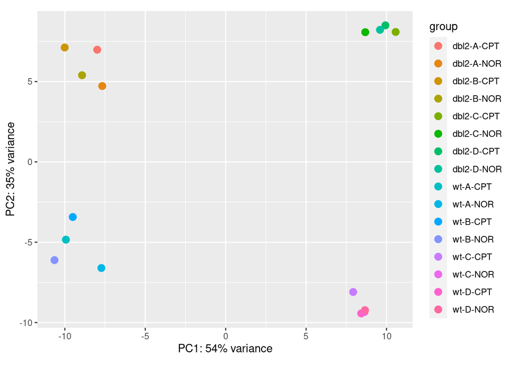

```r
dds <-DESeqDataSetFromMatrix(countData = Counts, colData = coldata, design = ~ gen_med)

dds <-DESeq(dds)
vsdata <- vst(dds, blind = F)

plotPCA(vsdata,intgroup="sample")
```

The PCA plot and QC of raw data showed a difference between A/B replicate and C/D, so I suppose that the replicates were from different runs, and PCA shows a batch effect. Therefore:

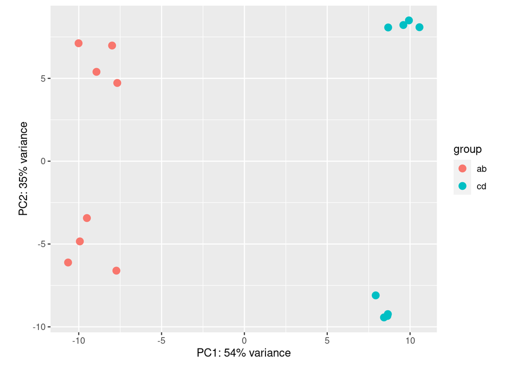

```r
run_ef<- factor(c("ab", "ab", "ab", "ab","cd", "cd", "cd", "cd", "ab", "ab", "ab", "ab", "cd", "cd", "cd",
"cd"))

coldata$run_ef <- run_ef

dds <-DESeqDataSetFromMatrix(countData = Counts, colData = coldata, design = ~ gen_med)
dds <-DESeq(dds)
vsdata <- vst(dds, blind = F)
plotPCA(vsdata,intgroup="run_ef")
```

```r
dds<-DESeqDataSetFromMatrix(countData = Counts, colData = coldata, design = ~ run_ef
+ medium + genotype)

dds$genotype <- relevel(dds$genotype, ref = 'wt')

padj_threshold <- 0.05

dds <- DESeq(dds)

res <- results(dds,lfcThreshold = 0.585, alpha = padj_threshold)
res_sig <- res[res$padj <= padj_threshold & !is.na(res$padj), ]

datatable(as.data.frame(res_sig), rownames = FALSE)
```

| baseMean | log2FoldChange | lfcSE | stat | pvalue | padj |
| --- | --- | --- | --- | --- | --- |
| 133.6107633939365 | 1.850437428017811 | 0.1232359369027271 | 10.26841244382026 | 9.780077881765842e-25 | 1.662864011127931e-22 |
| 24.47818476900698 | 1.786703982239773 | 0.2673794474590336 | 4.494376787968685 | 6.97739888382561e-06 | 0.0002422362931866368 |
| 41.03578448050244 | 2.289527457246451 | 0.1984247356467412 | 8.59029723129403 | 8.674462801280372e-18 | 8.987556693014085e-16 |
| 1147.870664493206 | 1.403155847014893 | 0.084919361052927 | 9.634503096472521 | 5.716791395706818e-22 | 8.240879074985196e-20 |
| 2033.792477950417 | 0.8613006038884438 | 0.05819708372554645 | 4.747670951889255 | 2.057724463227713e-06 | 7.622777047856403e-05 |
| 78.81611913238434 | 1.17126082661412 | 0.1174840921906608 | 4.990129435248973 | 6.03388475483492e-07 | 2.339806421597097e-05 |
| 70.33574680256024 | 1.965405216491946 | 0.1416024767746895 | 9.748453896667181 | 1.872989865723373e-22 | 2.75995462213593e-20 |
| 402.2101833188044 | 1.307208946490121 | 0.1286145391507714 | 5.615297860248092 | 1.962239292770904e-08 | 9.360869604578319e-07 |
| 443.5905662577509 | 1.138409107494999 | 0.06174485072779962 | 8.962838211961786 | 3.164266614285717e-19 | 3.61762964126355e-17 |
| 17.42225678532297 | 2.430345737505786 | 0.3138917702285293 | 5.878923605299623 | 4.129428823576424e-09 | 2.106326348395021e-07 |

[output cut: 267 more lines]

# Answers to exam questions:

## How many differentially expressed genes did you find (up and downregulated)?

```r
summary(res[res$padj <= padj_threshold & !is.na(res$padj), ])
```

```
##
## out of 277 with nonzero total read count
## adjusted p-value < 0.05
## LFC > 0.58 (up)    : 274, 99%
## LFC < -0.58 (down) : 3, 1.1%
## outliers [1]       : 0, 0%
## low counts [2]     : 0, 0%
## (mean count < 0)
## [1] see 'cooksCutoff' argument of ?results
## [2] see 'independentFiltering' argument of ?results
```

## How many of those DEGs were non-coding RNAs?

```bash
cd ${WORKDIR}/annotatoin
wget https://www.pombase.org/data/names_and_identifiers/gene_IDs_names_products.tsv
```

```r
pombase_an <- read_tsv("/home/kate/Bioinf/migexam/gene_IDs_names_products.tsv")
res <- res %>% as.data.frame() %>%  rownames_to_column("gene")
res <-res[res$padj <= padj_threshold & !is.na(res$padj), ]

num_non_c_RNA <- pombase_an %>%
  filter(gene_systematic_id %in% res$gene, grepl("^non-coding RNA", gene_product)) %>%
  nrow()
print(num_non_c_RNA)
```

```
## [1] 142
```